# lab10

Yuchen Song_201830360498 - Xuewen Wang_201830120252

2021/12/1

## The data

```r
load(url("http://www.openintro.org/stat/data/evals.RData"))
```

## Exploring the data

### Ex1

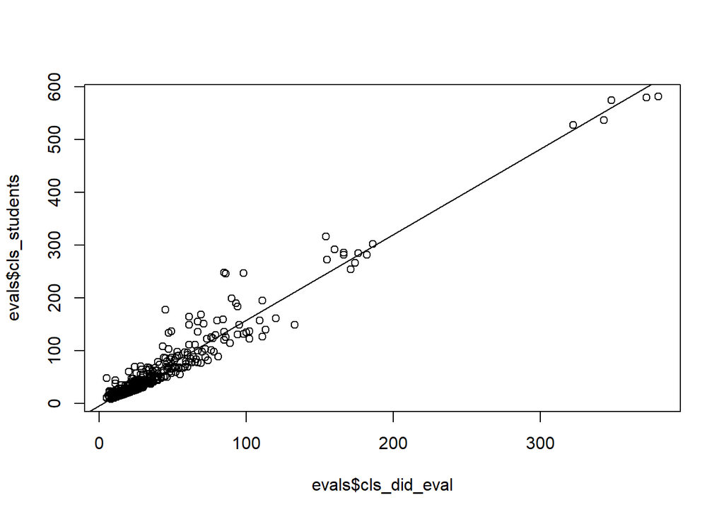

```r
plot(evals$cls_students~evals$cls_did_eval)
m1 <- lm(cls_students ~ cls_did_eval, data = evals)
abline(m1)
```

The two variables are approximately linear correlated.

## Simple linear regression

### Ex2

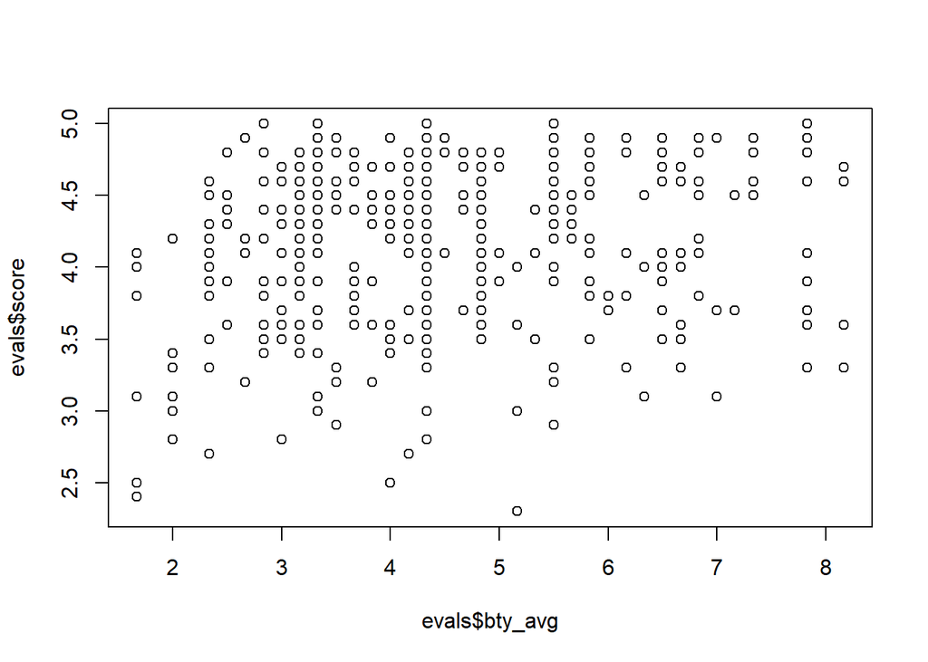

```r
plot(evals$score ~ evals$bty_avg)
```

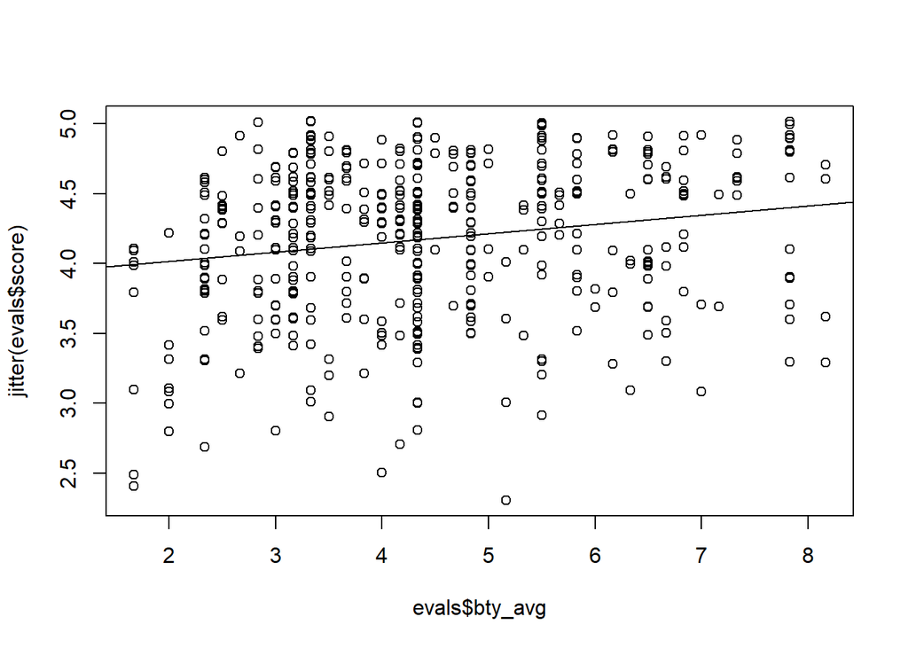

```r
plot(jitter(evals$score)~evals$bty_avg)
m_bty <- lm(score ~ bty_avg, data = evals)
abline(m_bty)
```

```r
summary(m_bty)
```

```
##
## Call:
## lm(formula = score ~ bty_avg, data = evals)
##
## Residuals:
##     Min      1Q  Median      3Q     Max
## -1.9246 -0.3690  0.1420  0.3977  0.9309
##
## Coefficients:
##             Estimate Std. Error t value Pr(>|t|)
## (Intercept)  3.88034    0.07614   50.96  < 2e-16 ***
## bty_avg      0.06664    0.01629    4.09 5.08e-05 ***
## ---
## Signif. codes:  0 '***' 0.001 '**' 0.01 '*' 0.05 '.' 0.1 ' ' 1
##
## Residual standard error: 0.5348 on 461 degrees of freedom
## Multiple R-squared:  0.03502,    Adjusted R-squared:  0.03293
## F-statistic: 16.73 on 1 and 461 DF,  p-value: 5.083e-05
```

The initial plot cannot show all the data points due to the coincide.  
$\hat{y}=b_0+b_1x$  
$\hat{score}=3.88034+0.06664\times bty\_avg$  
The slope means that when the average beauty rating of professor goes up 1 unit, the average professor evaluation score would raise about 0.06664 units.  
The P-value is small(5.08e-05), so the beauty score is a statistically significant predictor.  
On the other hand, whenever $bty\_avg$ goes up 1 unit, the $score$ only increases by 0.06664 units, which implies that this slope is not a practically significant predictor.

## Multiple linear regression

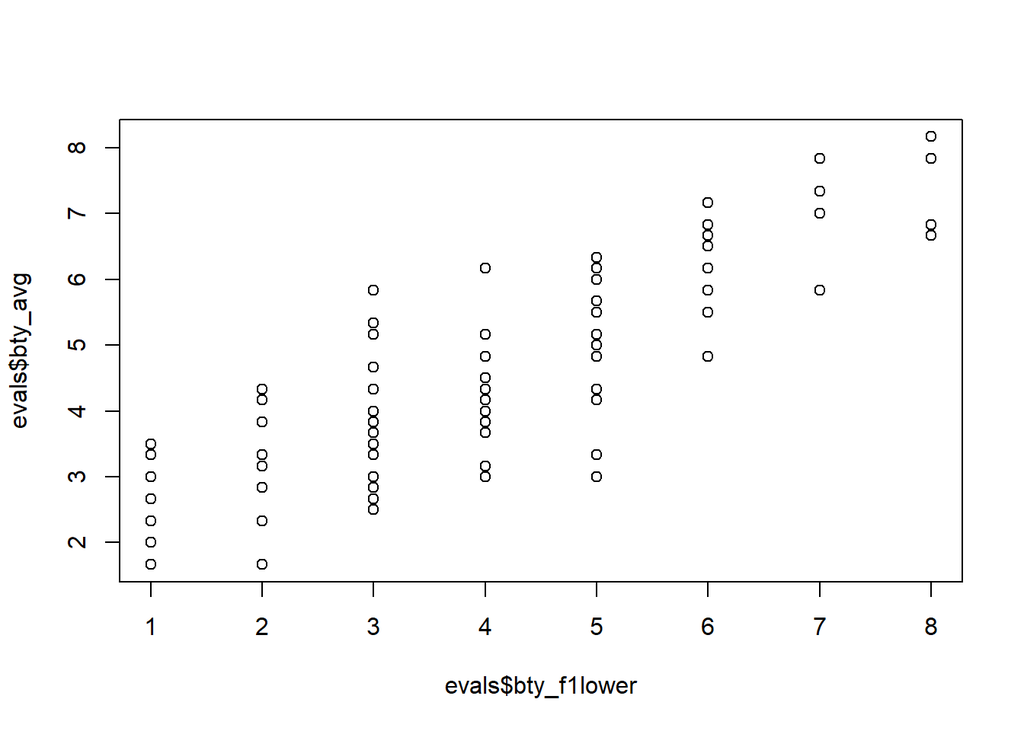

```r
plot(evals$bty_avg ~ evals$bty_f1lower)
```

```r
cor(evals$bty_avg, evals$bty_f1lower)
```

```
## [1] 0.8439112
```

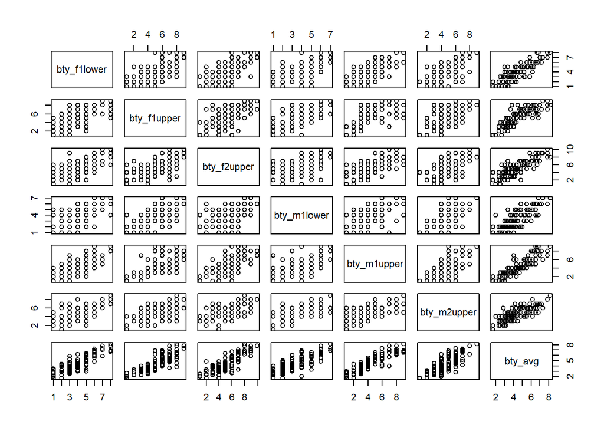

```r
plot(evals[,13:19])
```

```r
m_bty_gen = lm(score ~ bty_avg + gender, data = evals)
summary(m_bty_gen)
```

```
##
## Call:
## lm(formula = score ~ bty_avg + gender, data = evals)
##
## Residuals:
##     Min      1Q  Median      3Q     Max
## -1.8305 -0.3625  0.1055  0.4213  0.9314
##
## Coefficients:
##             Estimate Std. Error t value Pr(>|t|)
## (Intercept)  3.74734    0.08466  44.266  < 2e-16 ***
## bty_avg      0.07416    0.01625   4.563 6.48e-06 ***
## gendermale   0.17239    0.05022   3.433 0.000652 ***
## ---
## Signif. codes:  0 '***' 0.001 '**' 0.01 '*' 0.05 '.' 0.1 ' ' 1
##
## Residual standard error: 0.5287 on 460 degrees of freedom
## Multiple R-squared:  0.05912,    Adjusted R-squared:  0.05503
## F-statistic: 14.45 on 2 and 460 DF,  p-value: 8.177e-07
```

### Ex3

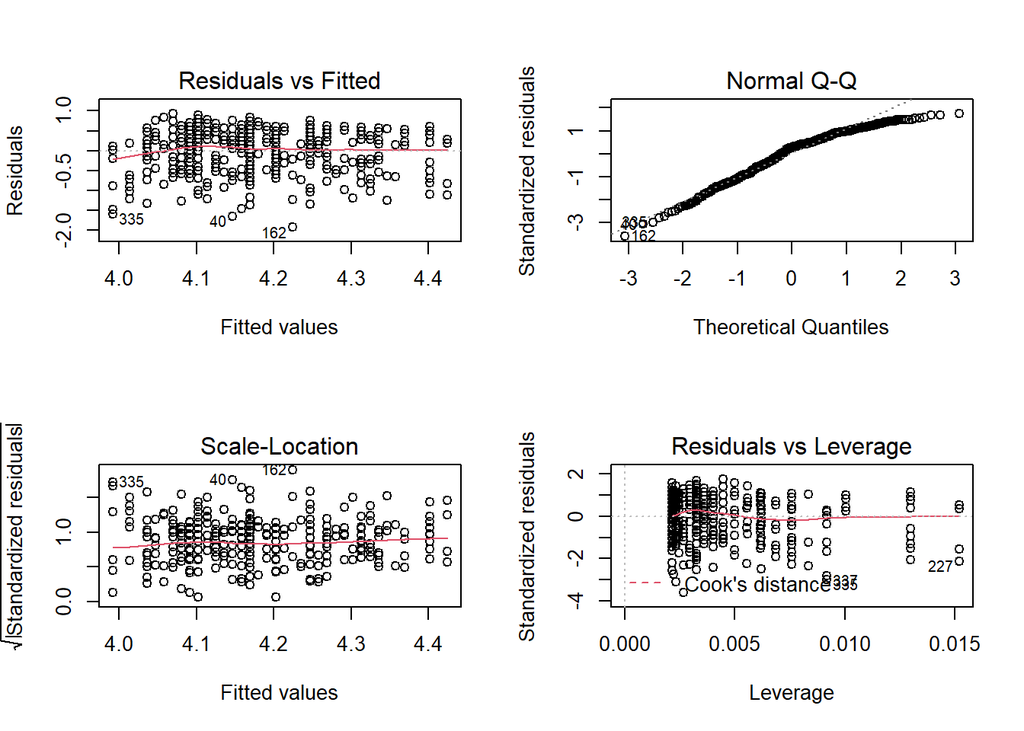

```r
par(mfrow = c(2, 2))
plot(m_bty)
```

The conditions for linear regression is:  
Independence, Linear Relationship, Constant Variance, Normality of Residuals, and No Influential Points.  
Firstly, independence is met by the question specification.  
Secondly, as we can see in the previous scatter plot, the variable is roughly linear.  
Thirdly, in the residual plot, all the residuals are evenly distributed within the two parallel lines around the center line.  
Fourthly, from the qqplot, the residuals are approximately in a straight line, so the Normality of Residuals condition can be met.  
Fifthly, In the Residuals vs Leverage plot, we see no points with large Cook’s Distance(greater than 5 or 10).

### Ex4

Yes, it is. Because the P-value is still very small(6.48e-06).  
Yes, the parameter estimate has been changed to $\hat{\beta}_0=3.74734,\ \hat{\beta}_1=0.07416,\ and\ \hat{\beta}_2=0.17239$, and the model for male is:  
$\hat{score}=3.74734+0.07416\times beauty\_avg+0.17239$  
Male professors tend to have higher evaluation score.

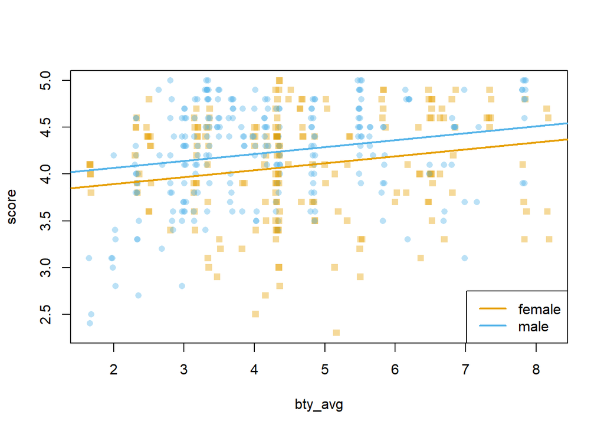

```r
multiLines(m_bty_gen)
```

```r
m_bty_rank = lm(score ~ bty_avg + rank, data = evals)
summary(m_bty_rank)
```

```
##
## Call:
## lm(formula = score ~ bty_avg + rank, data = evals)
##
## Residuals:
##     Min      1Q  Median      3Q     Max
## -1.8713 -0.3642  0.1489  0.4103  0.9525
##
## Coefficients:
##                  Estimate Std. Error t value Pr(>|t|)
## (Intercept)       3.98155    0.09078  43.860  < 2e-16 ***
## bty_avg           0.06783    0.01655   4.098 4.92e-05 ***
## ranktenure track -0.16070    0.07395  -2.173   0.0303 *
## ranktenured      -0.12623    0.06266  -2.014   0.0445 *
## ---
## Signif. codes:  0 '***' 0.001 '**' 0.01 '*' 0.05 '.' 0.1 ' ' 1
##
## Residual standard error: 0.5328 on 459 degrees of freedom
## Multiple R-squared:  0.04652,    Adjusted R-squared:  0.04029
## F-statistic: 7.465 on 3 and 459 DF,  p-value: 6.88e-05
```

R adds another line to it, and then, like the 2 levels categories one.

## The search for the best model

### Ex6

We expect that the variable cls_students has the highest p-value.  
Because total number of students in class has little to do with the evaluate score, as we can guess.

### Ex7

```r
m_full <- lm(score ~ rank + ethnicity + gender + language + age + cls_perc_eval
             + cls_students + cls_level + cls_profs + cls_credits + bty_avg
             + pic_outfit + pic_color, data = evals)
summary(m_full)
```

```
##
## Call:
## lm(formula = score ~ rank + ethnicity + gender + language + age +
##     cls_perc_eval + cls_students + cls_level + cls_profs + cls_credits +
##     bty_avg + pic_outfit + pic_color, data = evals)
##
## Residuals:
##      Min       1Q   Median       3Q      Max
## -1.77397 -0.32432  0.09067  0.35183  0.95036
##
## Coefficients:
##                         Estimate Std. Error t value Pr(>|t|)
## (Intercept)            4.0952141  0.2905277  14.096  < 2e-16 ***
## ranktenure track      -0.1475932  0.0820671  -1.798  0.07278 .
## ranktenured           -0.0973378  0.0663296  -1.467  0.14295
## ethnicitynot minority  0.1234929  0.0786273   1.571  0.11698
## gendermale             0.2109481  0.0518230   4.071 5.54e-05 ***
## languagenon-english   -0.2298112  0.1113754  -2.063  0.03965 *
## age                   -0.0090072  0.0031359  -2.872  0.00427 **
## cls_perc_eval          0.0053272  0.0015393   3.461  0.00059 ***
## cls_students           0.0004546  0.0003774   1.205  0.22896
## cls_levelupper         0.0605140  0.0575617   1.051  0.29369
## cls_profssingle       -0.0146619  0.0519885  -0.282  0.77806
## cls_creditsone credit  0.5020432  0.1159388   4.330 1.84e-05 ***
## bty_avg                0.0400333  0.0175064   2.287  0.02267 *
## pic_outfitnot formal  -0.1126817  0.0738800  -1.525  0.12792
## pic_colorcolor        -0.2172630  0.0715021  -3.039  0.00252 **
## ---
## Signif. codes:  0 '***' 0.001 '**' 0.01 '*' 0.05 '.' 0.1 ' ' 1
##
## Residual standard error: 0.498 on 448 degrees of freedom
## Multiple R-squared:  0.1871, Adjusted R-squared:  0.1617
## F-statistic: 7.366 on 14 and 448 DF,  p-value: 6.552e-14
```

Our guess in the previous exercise was incorrect, since the variable cls_prof has the largest p-value(0.77806), which indicates that it has least association with the professor’s evaluation score.

### Ex8

```r
m_full <- lm(score ~ rank + ethnicity + gender + language + age + cls_perc_eval
             + cls_students + cls_level + cls_credits + bty_avg
             + pic_outfit + pic_color, data = evals)
summary(m_full)
```

```
##
## Call:
## lm(formula = score ~ rank + ethnicity + gender + language + age +
##     cls_perc_eval + cls_students + cls_level + cls_credits +
##     bty_avg + pic_outfit + pic_color, data = evals)
##
## Residuals:
##     Min      1Q  Median      3Q     Max
## -1.7836 -0.3257  0.0859  0.3513  0.9551
##
## Coefficients:
##                         Estimate Std. Error t value Pr(>|t|)
## (Intercept)            4.0872523  0.2888562  14.150  < 2e-16 ***
## ranktenure track      -0.1476746  0.0819824  -1.801 0.072327 .
## ranktenured           -0.0973829  0.0662614  -1.470 0.142349
## ethnicitynot minority  0.1274458  0.0772887   1.649 0.099856 .
## gendermale             0.2101231  0.0516873   4.065 5.66e-05 ***
## languagenon-english   -0.2282894  0.1111305  -2.054 0.040530 *
## age                   -0.0089992  0.0031326  -2.873 0.004262 **
## cls_perc_eval          0.0052888  0.0015317   3.453 0.000607 ***
## cls_students           0.0004687  0.0003737   1.254 0.210384
## cls_levelupper         0.0606374  0.0575010   1.055 0.292200
## cls_creditsone credit  0.5061196  0.1149163   4.404 1.33e-05 ***
## bty_avg                0.0398629  0.0174780   2.281 0.023032 *
## pic_outfitnot formal  -0.1083227  0.0721711  -1.501 0.134080
## pic_colorcolor        -0.2190527  0.0711469  -3.079 0.002205 **
## ---
## Signif. codes:  0 '***' 0.001 '**' 0.01 '*' 0.05 '.' 0.1 ' ' 1
##
## Residual standard error: 0.4974 on 449 degrees of freedom
## Multiple R-squared:  0.187,  Adjusted R-squared:  0.1634
## F-statistic: 7.943 on 13 and 449 DF,  p-value: 2.336e-14
```

Basically the coefficients and significance of the other explanatory variables do not change much.  
This implies that the dropped variable was non collinear with the other explanatory variables.

### Ex9

```r
m_full_final <- lm(score ~ ethnicity + gender + language + age + cls_perc_eval + cls_credits + bty_avg + pic_color, data = evals)
summary(m_full_final)
```

```
##
## Call:
## lm(formula = score ~ ethnicity + gender + language + age + cls_perc_eval +
##     cls_credits + bty_avg + pic_color, data = evals)
##
## Residuals:
##      Min       1Q   Median       3Q      Max
## -1.85320 -0.32394  0.09984  0.37930  0.93610
##
## Coefficients:
##                        Estimate Std. Error t value Pr(>|t|)
## (Intercept)            3.771922   0.232053  16.255  < 2e-16 ***
## ethnicitynot minority  0.167872   0.075275   2.230  0.02623 *
## gendermale             0.207112   0.050135   4.131 4.30e-05 ***
## languagenon-english   -0.206178   0.103639  -1.989  0.04726 *
## age                   -0.006046   0.002612  -2.315  0.02108 *
## cls_perc_eval          0.004656   0.001435   3.244  0.00127 **
## cls_creditsone credit  0.505306   0.104119   4.853 1.67e-06 ***
## bty_avg                0.051069   0.016934   3.016  0.00271 **
## pic_colorcolor        -0.190579   0.067351  -2.830  0.00487 **
## ---
## Signif. codes:  0 '***' 0.001 '**' 0.01 '*' 0.05 '.' 0.1 ' ' 1
##
## Residual standard error: 0.4992 on 454 degrees of freedom
## Multiple R-squared:  0.1722, Adjusted R-squared:  0.1576
## F-statistic:  11.8 on 8 and 454 DF,  p-value: 2.58e-15
```

### Ex10

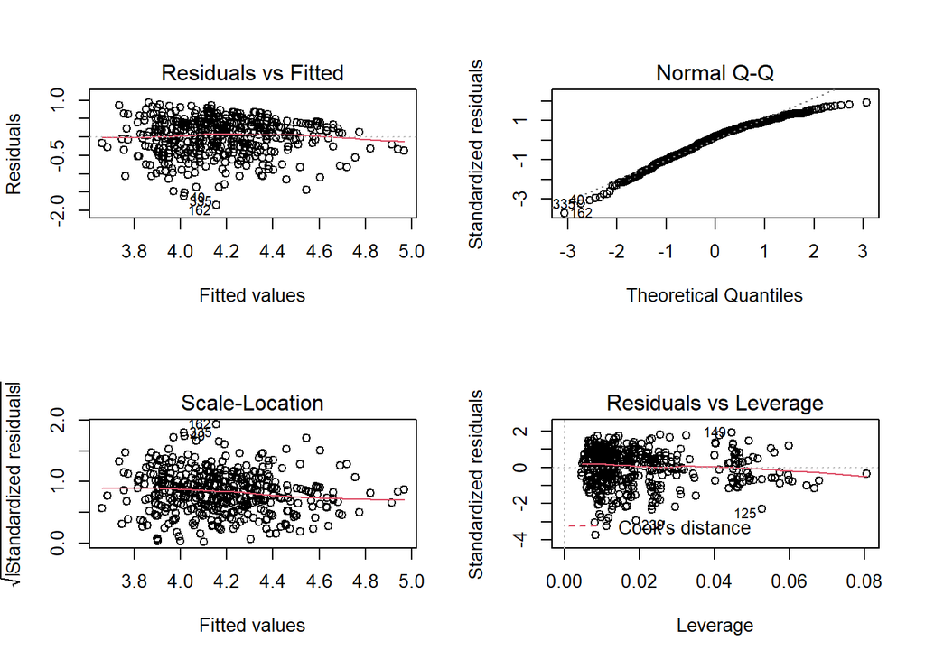

```r
par(mfrow = c(2, 2))
plot(m_full_final)
```

Similar analysis as exercise 3, we find that all 5 conditions can be met well for our final model.  
The conditions for linear regression is:  
Independence, Linear Relationship, Constant Variance, Normality of Residuals, and No Influential Points.  
Firstly, independence is met by the question specification.  
Secondly, as we can see in the previous scatter plot, the variable is roughly linear.  
Thirdly, in the residual plot, all the residuals are evenly distributed within the two parallel lines around the center line.  
Fourthly, from the qqplot, the residuals are approximately in a straight line, so the Normality of Residuals condition can be met.  
Fifthly, In the Residuals vs Leverage plot, we see no points with large Cook’s Distance(greater than 5 or 10).